# W2-Reproducible research

JBO

7/11/2020

## Project overview

This assignment consist of showing various key figures for a persons number of steps logged with 5 minute intervals over a 2 month period from 10/01/2012 to 11/30/2012.

## Needed packages

The following packages are needed for the analysis to run:

```r
library(dplyr)
library(ggplot2)
library(knitr)
library(lubridate)
```

### Loading and Preprocessing the data

Here we read in the given data and make sure the date column is treated as dates instead of characters.

```r
dat<-read.csv("activity.csv")
dat$date<-as.Date(dat$date)
```

### What is mean total number of steps taken per day?

To see how the persons steps a distributed on a daily basis we create a new data frame that conist of total number of steps taken each days. NA’s are removed.

```r
df_steps_day<-dat %>%
  filter(!is.na(steps)) %>%
  mutate(date = floor_date(date)) %>%
  group_by(date) %>%
  summarize(total_steps = sum(steps))
```

With this new data frame we can plot the histogram of the total number of steps taken:

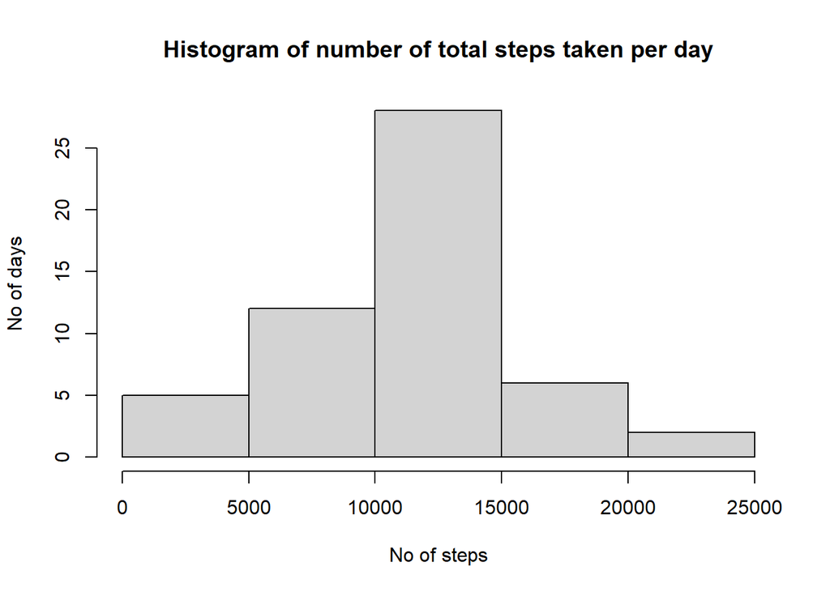

```r
hist(df_steps_day$total_steps,ylab="No of days", xlab = "No of steps", main = "Histogram of number of total steps taken per day")
```

We can further get the mean:

```r
mean(df_steps_day$total_steps)
```

```
## [1] 10766.19
```

and the median

```r
median(df_steps_day$total_steps)
```

```
## [1] 10765
```

## What is the average daily activity pattern?

We create a new data frame that provides the mean number of steps taken at each interval, disregarding NA’s.

```r
df_interval<-dat %>%
  filter(!is.na(steps)) %>%
  group_by(interval) %>%
  summarize(mean_steps = mean(steps))
```

With this new data fram we can see how the avergae number of steps changes over the intervals.

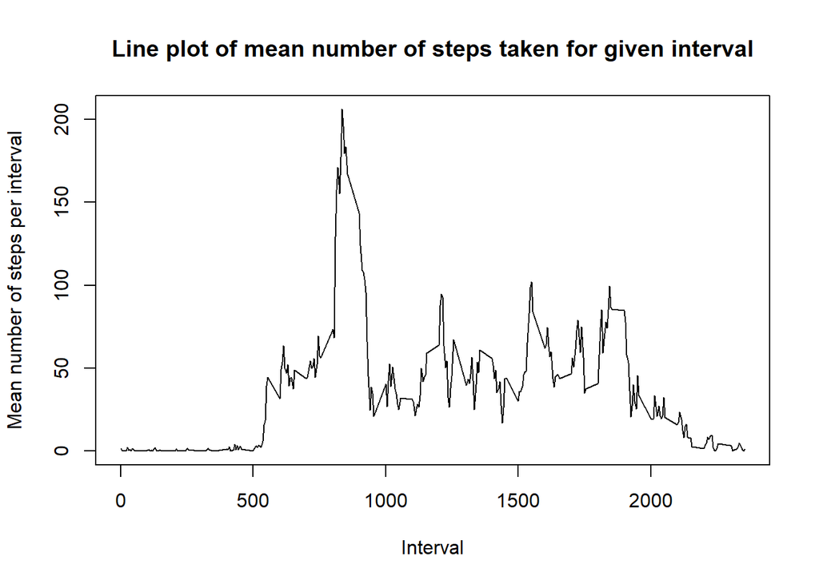

```r
with(df_interval, plot(interval,mean_steps,type = "l",ylab="Mean number of steps per interval",
                       xlab = "Interval", main = "Line plot of mean number of steps taken for given interval"))
```

The interval with the highest number of mean steps can be found via:

```r
df_interval$interval[which.max(df_interval$mean_steps)]
```

```
## [1] 835
```

## Imputing missing values

First we find how many NA’s the dataset actually contains

```r
sum(is.na(dat$steps))
```

```
## [1] 2304
```

Instead of just removing NA’s all together I will instead fill any missing value with the average value for the iven interval and day.  
To this end I use the weekdays function to distinguish between days and create a lookup data fram with the mean number of steps taken per interval and day.

```r
df_interpolate<-dat %>%
  filter(!is.na(steps)) %>%
  mutate(day_no = weekdays(date)) %>%
  group_by(interval,day_no) %>%
  summarize(mean_steps = mean(steps))
```

Having this lookup table available I can loop through the raw data frame and exchange the NA’s with the values from the just calculated data frame.

```r
dat_int<-dat
for (i in 1:nrow(dat)){
  if (is.na(dat$steps[i])){
    dat_int$steps[i]<-df_interpolate$mean_steps[which(df_interpolate$day_no==weekdays(dat$date[i])
                                                  & df_interpolate$interval==dat$interval[i])]
  }
}
```

As earlier we can now find the total number of steps taken

```r
df_steps_day1<-dat_int %>%
  mutate(date = floor_date(date)) %>%
  group_by(date) %>%
  summarize(total_steps = sum(steps))
```

and the histogram of those.

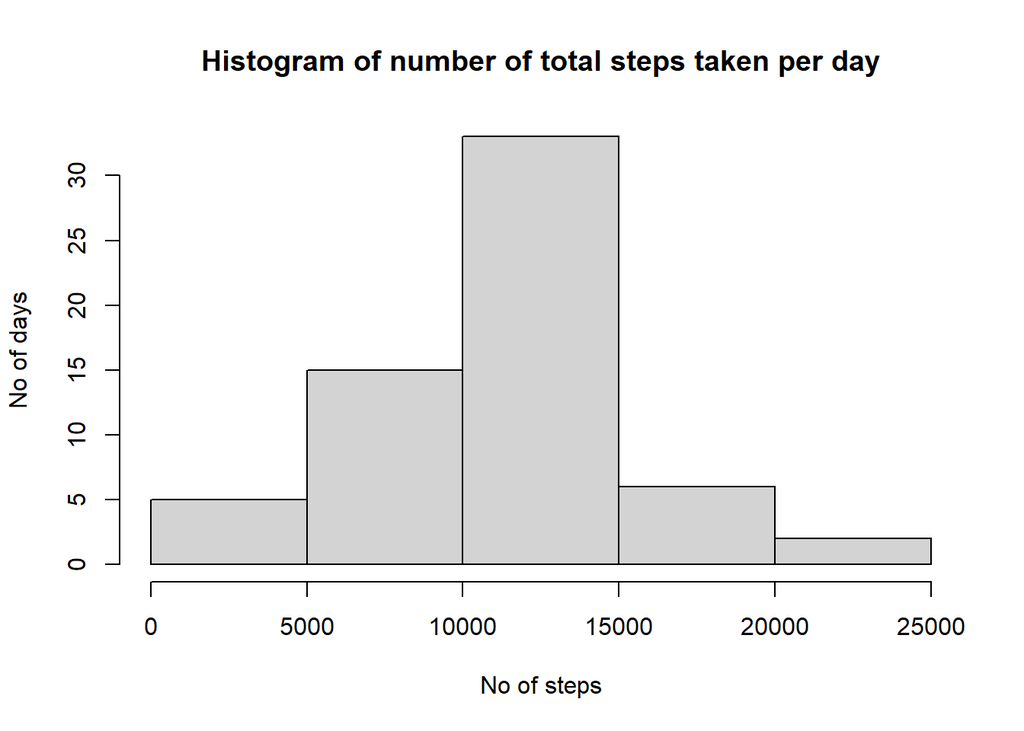

```r
hist(df_steps_day1$total_steps,ylab="No of days", xlab = "No of steps", main = "Histogram of number of total steps taken per day")
```

Mean total number of steps

```r
mean(df_steps_day1$total_steps)
```

```
## [1] 10821.21
```

and median

```r
median(df_steps_day1$total_steps)
```

```
## [1] 11015
```

```r
df_week<-dat_int %>%
  mutate(date = floor_date(date)) %>%
  mutate(day_type = if_else(wday(date,week_start = 1)<6,"Weekday","Weekend")) %>%
  group_by(interval,day_type) %>%
  summarize(mean_steps = mean(steps))
```

A plot using the facet system from ggplot2 can now be shown.

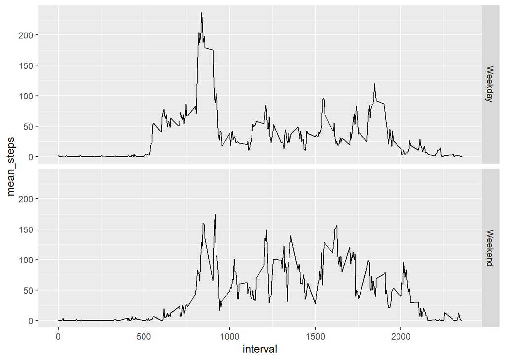

```r
ggplot(df_week, aes(x=interval, y=mean_steps))+geom_line() +facet_grid(day_type~.)
```

From these graphs it seems fair to say that the persons activity level depends on it being either a weekday or weekend.